# Ensemble Techniques Project

#### Inferences:

- MDVP:Fo(Hz) - Average vocal fundamental frequency of a person suffering by PD is less than by 36Hz compared to a healthy person.
- MDVP:Fhi(Hz) - Maximum vocal fundamental frequency of a person suffering by PD is less than by 35Hz compared to a healthy person.
- MDVP:Flo(Hz) - Minimum vocal fundamental frequency of a person suffering by PD is less than by 39Hz compared to a healthy person.
- MDVP:Jitter(%),MDVP:Jitter(Abs),MDVP:RAP,MDVP:PPQ,Jitter:DDP - Several measures of variation in fundamental frequency have considerable differences between a healthy person & a person suffering from PD.
- DVP:Shimmer,MDVP:Shimmer(dB),Shimmer:APQ3,Shimmer:APQ5,MDVP:APQ,Shimmer:DDA - Several measures of variation in amplitude also have considerable differences between a healthy person & a person suffering from PD.
- NHR,HNR - Two measures of ratio of noise to tonal components in the voice also have considerable differences.

*Similar differences are observed in other features too*

```python
#Checking for skewness

for feature in parkDF.columns:
     if((feature != 'name') and (feature != 'status')):
            print(feature,"===>",parkDF[feature].skew())

# We can observe that many of the features are skewed. Mostly positively skewed.
```

```
MDVP:Fo(Hz) ===> 0.5917374636540784
MDVP:Fhi(Hz) ===> 2.542145997588398
MDVP:Flo(Hz) ===> 1.217350448627808
MDVP:Jitter(%) ===> 3.0849462014441817
MDVP:Jitter(Abs) ===> 2.6490714165257274
MDVP:RAP ===> 3.360708450480554
MDVP:PPQ ===> 3.073892457888517
Jitter:DDP ===> 3.3620584478857203
MDVP:Shimmer ===> 1.6664804101559663
MDVP:Shimmer(dB) ===> 1.999388639086127
Shimmer:APQ3 ===> 1.5805763798815677
Shimmer:APQ5 ===> 1.798697066537622
MDVP:APQ ===> 2.618046502215422
Shimmer:DDA ===> 1.5806179936782263
NHR ===> 4.22070912913906
HNR ===> -0.5143174975652068
RPDE ===> -0.14340241379821705
DFA ===> -0.03321366071383484
spread1 ===> 0.4321389320131796
spread2 ===> 0.14443048549278412
D2 ===> 0.4303838913329283
PPE ===> 0.7974910716463578
```

```python
# Checking for Null Values

parkDF.isnull().any()
```

```
name                False
MDVP:Fo(Hz)         False
MDVP:Fhi(Hz)        False
MDVP:Flo(Hz)        False
MDVP:Jitter(%)      False
MDVP:Jitter(Abs)    False
MDVP:RAP            False
MDVP:PPQ            False
Jitter:DDP          False
MDVP:Shimmer        False
MDVP:Shimmer(dB)    False
Shimmer:APQ3        False
Shimmer:APQ5        False
MDVP:APQ            False
Shimmer:DDA         False
NHR                 False
HNR                 False
RPDE                False
DFA                 False
spread1             False
spread2             False
D2                  False
PPE                 False
status              False
dtype: bool
```

```python
parkDF.isna().any()
```

```
name                False
MDVP:Fo(Hz)         False
MDVP:Fhi(Hz)        False
MDVP:Flo(Hz)        False
MDVP:Jitter(%)      False
MDVP:Jitter(Abs)    False
MDVP:RAP            False
MDVP:PPQ            False
Jitter:DDP          False
MDVP:Shimmer        False
MDVP:Shimmer(dB)    False
Shimmer:APQ3        False
Shimmer:APQ5        False
MDVP:APQ            False
Shimmer:DDA         False
NHR                 False
HNR                 False
RPDE                False
DFA                 False
spread1             False
spread2             False
D2                  False
PPE                 False
status              False
dtype: bool
```

```python
parkDF.duplicated().any()
```

```
False
```

##### Comment:

There are No null values, No N/A values and No duplicate values om the dataset

### 3. Using univariate & bivariate analysis to check theindividual attributes for their basic statistics such as central values, spread, tails, relationships between variables etc. mention your observations (15 points)

### *UNIVARIATE ANALYSIS*

(Analysis of distributions of continuous features)

```
MDVP:Fo(Hz)  Mean - Median =  5.4386
MDVP:Fo(Hz)  3 Standard Deviation below mean  30.0584
MDVP:Fo(Hz)  3 Standard Deviation above mean  278.3988
```

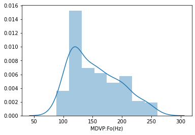

```python
feature = 'MDVP:Fo(Hz)'
mean_minus_median = np.round(parkDF[feature].mean(),4)  -  np.round((parkDF[feature].median()),4)
print(feature," Mean - Median = ",np.round(mean_minus_median,4))
minus3std = np.round(parkDF[feature].mean(),4)  -  np.round((3*parkDF[feature].std()),4)
print(feature," 3 Standard Deviation below mean ",np.round(minus3std,4))
plus3std = np.round(parkDF[feature].mean(),4) + np.round((3*parkDF[feature].std()),4)
print(feature," 3 Standard Deviation above mean ",np.round(plus3std,4))
sns.distplot(parkDF["MDVP:Fo(Hz)"])
plt.show()
```